# MB5370 Module 04. Data Science in R 1

### facet_grid by just row (or column)

Use a . if you don’t want to facet in the rows or column dimension

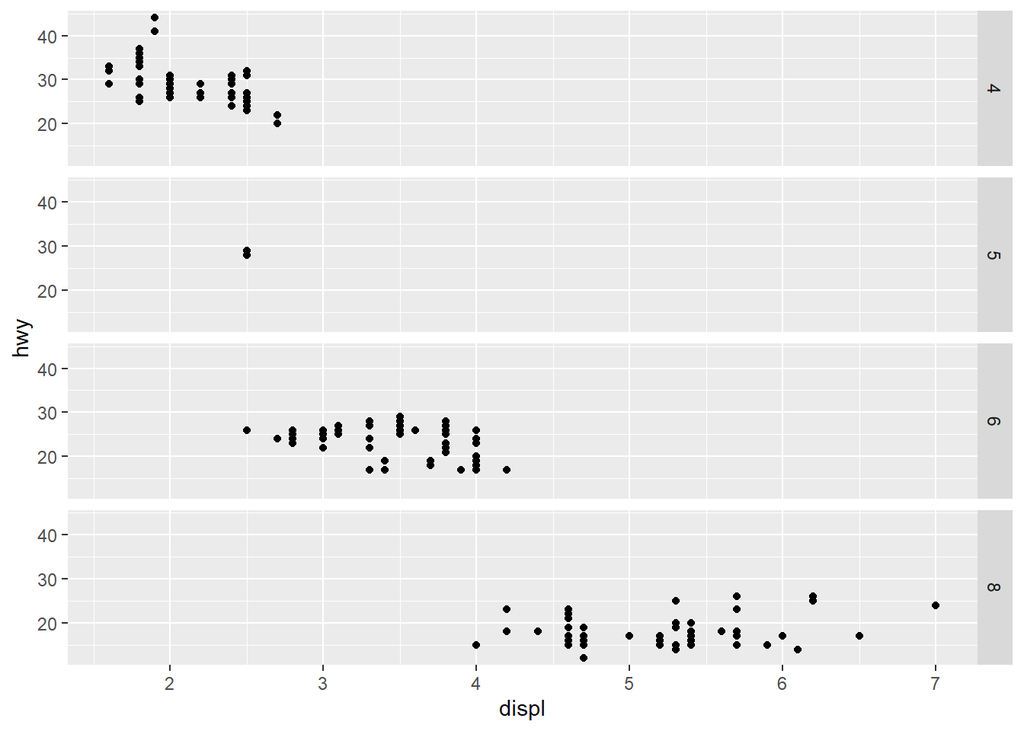

```r
ggplot(data = mpg) +
  geom_point(mapping = aes(x = displ, y = hwy)) +
  facet_grid(cyl ~ .)
```

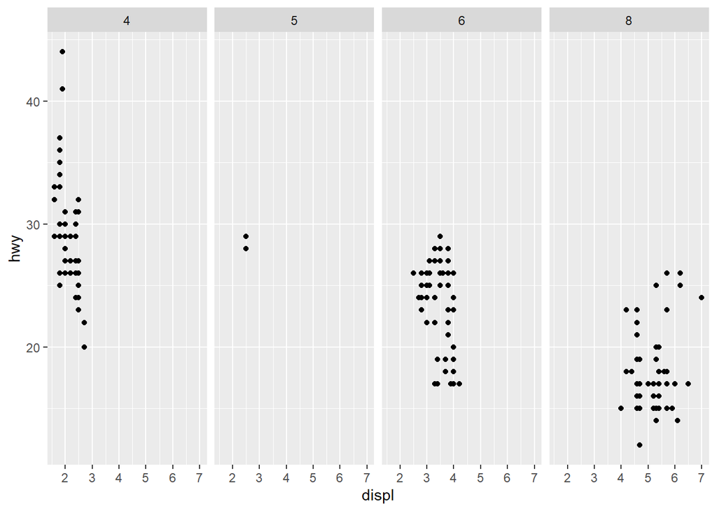

```r
  #facet_grid(. ~ cyl) # Alternatively

ggplot(data = mpg) +
  geom_point(mapping = aes(x = displ, y = hwy)) +
  facet_grid(. ~ cyl)
```

## Exercise 1:

Read ?facet_wrap. What does nrow do? What does ncol do? What other options control the layout of the individual panels?

```r
?facet_wrap # Pulls up the Help tab explaining the arguments of this function and what it is used for.
```

```
## starting httpd help server ... done
```

nrows is the number of rows, ncol is the number of columns, shrink is used with scales. If it’s true that the scale needs to be fixed, it will shrink the output of statistics. Axes determines which axes will be drawn in the case of fixed scales. Margins is the default for axes.

## Fitting Simple Lines

We already used points above.

However, ggplot2 can use a variety of geom objects to represent the data. We might want to use bar plots, line charts, box plots and so on. We can handle this issue in ggplot directly using a different geom to plot the same data. Here, instead of plotting points, we will use a smooth line.

### To display the same data as a smooth line fit through the points use geom_smooth().

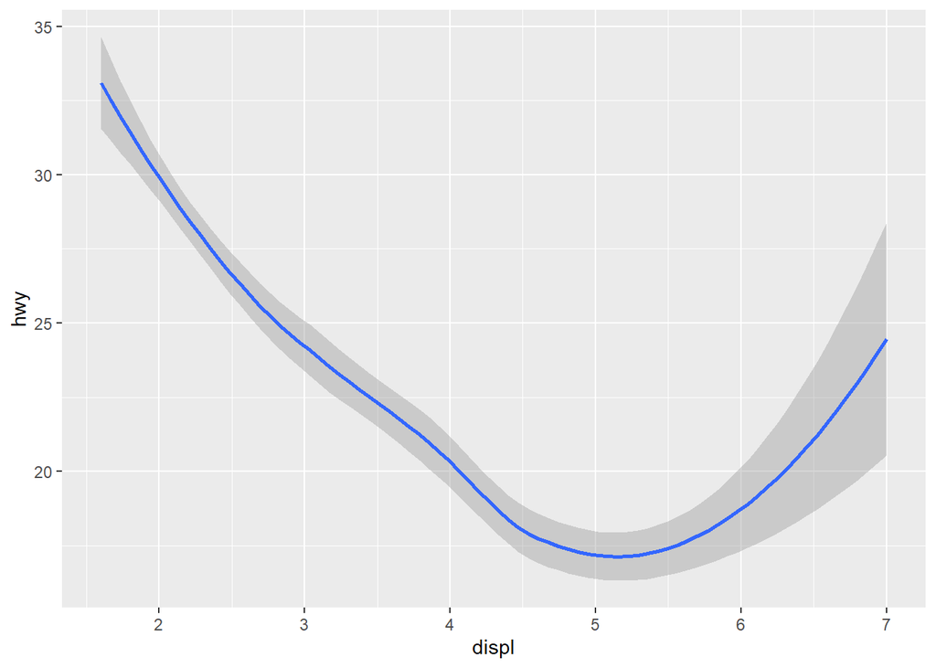

```r
ggplot(data = mpg) +
  #geom_point(mapping = aes(x = displ, y = hwy)) + # points horrible
  geom_smooth(mapping = aes(x = displ, y = hwy)) # try smooth line
```

So let’s recap. A geom is an object that your plot uses to represent the data. To change the geom type in your plot, simply change the geom function that you add to your plot template. Sometimes you may want to try a few things out, in which case you could use comments to help you remember what worked and what didn’t.

### Changing linetype

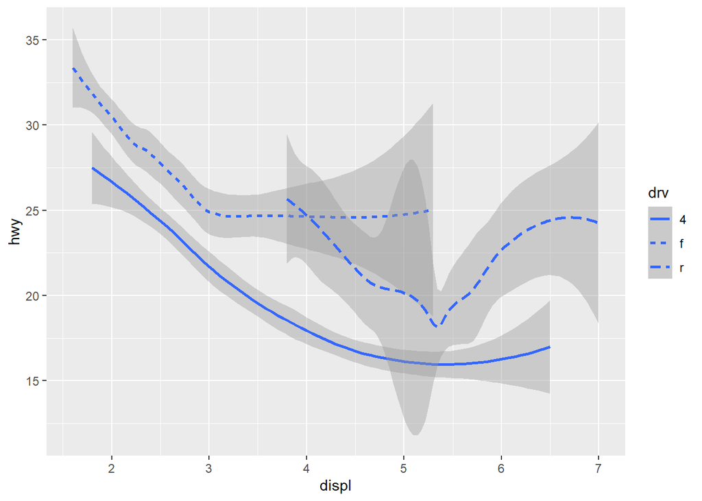

```r
ggplot(data = mpg) +
  geom_smooth(mapping = aes(x = displ, y = hwy, linetype = drv))
```

```r
# Can also use "lty = " for the same result
```

To set the lines to different colors, you must input the variable you want the colors to be based on

## Complex Plots in ggplot

### Change line color based on drv value

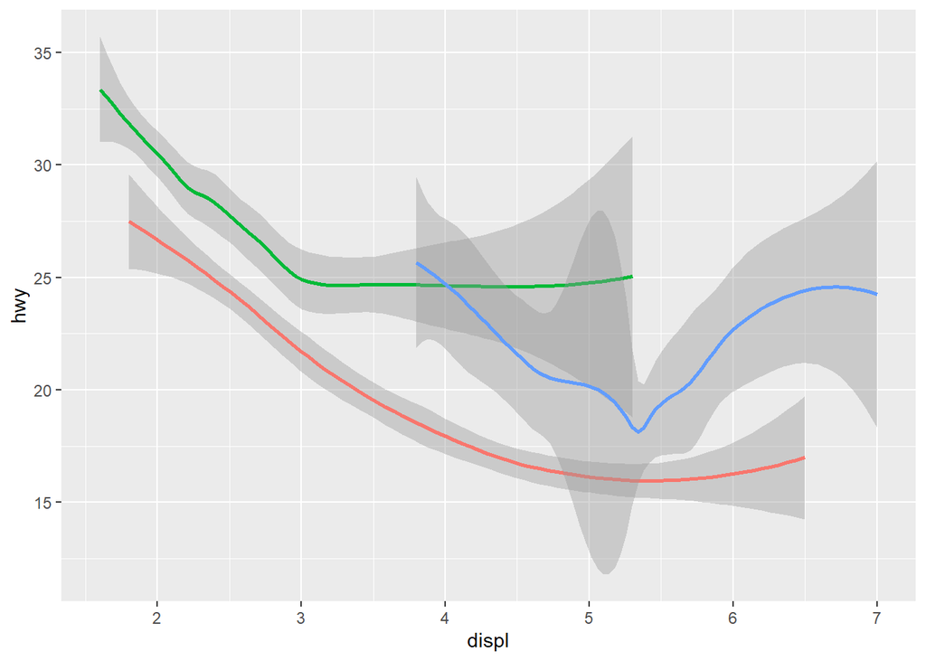

```r
ggplot(data = mpg) +
  geom_smooth(
    mapping = aes(x = displ, y = hwy, color = drv),
    show.legend = FALSE,
  )
```

### Multiple geoms

We already did this one way

```r
ggplot(data = mpg) +
  geom_point(mapping = aes(x = displ, y = hwy)) +
  geom_smooth(mapping = aes(x = displ, y = hwy))
```

With the above code, the top and second rows are duplicates so if you wanted to change the x variable you’d have to do it in multiple locations

A better way… you can make global mappings so you’d only have to change it in one location.

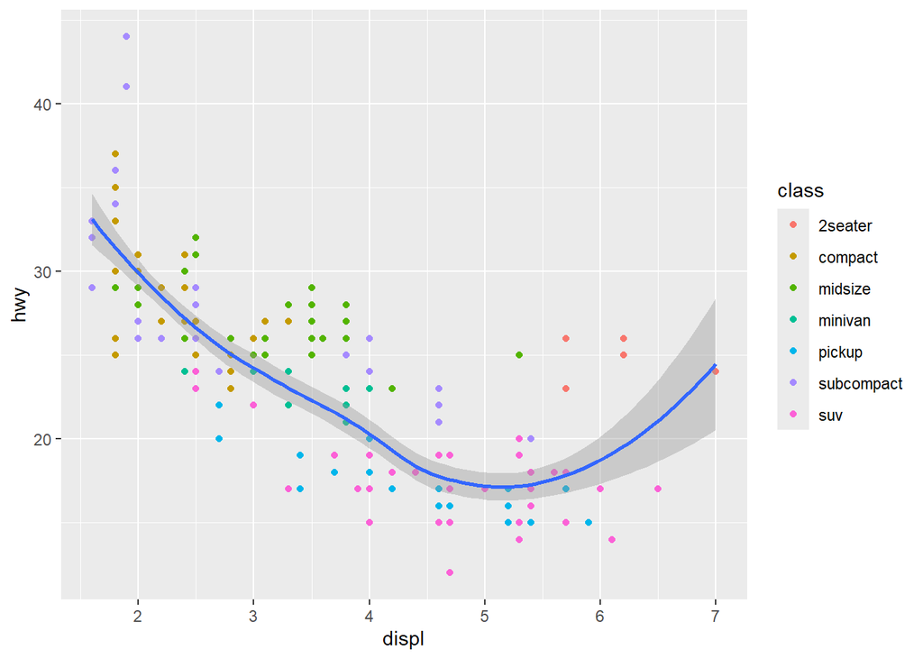

```r
ggplot(data = mpg, mapping = aes(x = displ, y = hwy)) +
  geom_point() +
  geom_smooth()
ggplot(data = mpg, mapping = aes(x = displ, y = hwy)) +
  geom_point(mapping = aes(color = class)) +
  geom_smooth()
```

By doing this, you can change certain features of one set without impacting the other.Now we have different colors to indicate the raw data (geom_point) and one color for the overall relationship (geom_smooth). Neat!

### Specifying different data for each layer using a filter called “subcompact” to select a subset of the data and plot ONLY that subset

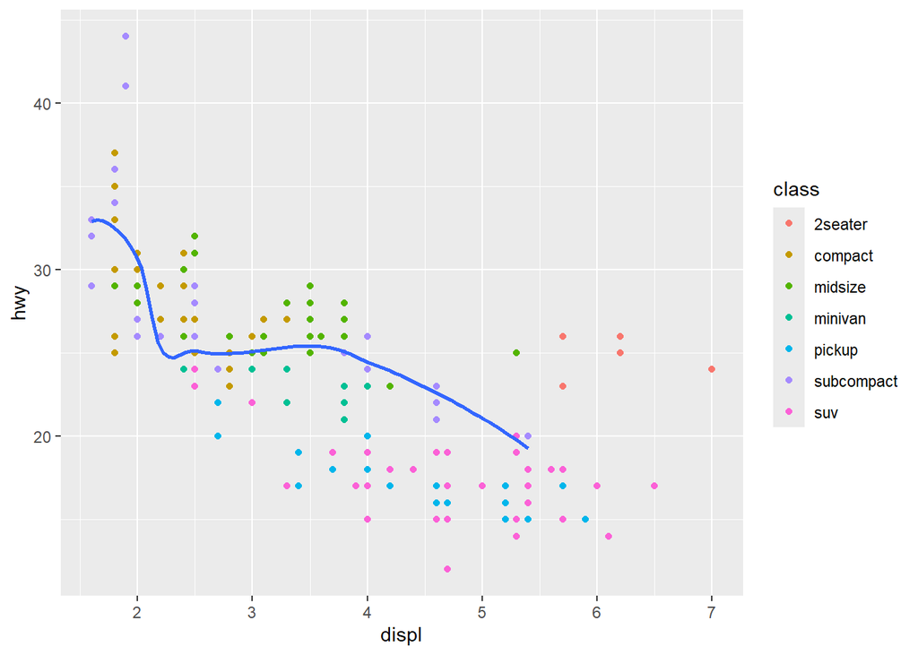

```r
ggplot(data = mpg, mapping = aes(x = displ, y = hwy)) +
  geom_point(mapping = aes(color = class)) +
  geom_smooth(data = filter(mpg, class == "subcompact"), se = FALSE)
```

## Exercise 2:

1. What geom would you use to draw a line chart? A boxplot? A histogram? An area chart?
- Use geom_line for a line chart, geom_boxplot for a box plot, geom_histogram for a histogram, and geom_area for an area plot.
2. Run this code in your head and predict what the output will look like. Then, run the code in R and check your predictions.
- Prediction: The code will give us the same plot from earlier (right above Exercise 2 in Multiple geoms). One chart using both point data and a smooth line (kinda like a line of best fit).

```r
ggplot(data = mpg, mapping = aes(x = displ, y = hwy)) +
  geom_point() +
  geom_smooth()
ggplot() +
  geom_point(data = mpg, mapping = aes(x = displ, y = hwy)) +
  geom_smooth(data = mpg, mapping = aes(x = displ, y = hwy))
```

3. Will these two graphs look different? Why/why not?

```r
ggplot(data = mpg, mapping = aes(x = displ, y = hwy)) +
  geom_point() +
  geom_smooth()
ggplot() +
  geom_point(data = mpg, mapping = aes(x = displ, y = hwy)) +
  geom_smooth(data = mpg, mapping = aes(x = displ, y = hwy))
```

The above code give the same result because, as we saw earlier, you can duplicate the data or make it global. In the bottom code, we have simply duplicated the data in the top code.

## Transformations and stats

### Load diamond data

```r
data("diamonds")
glimpse(diamonds)
```

```
## Rows: 53,940
## Columns: 10
## $ carat   <dbl> 0.23, 0.21, 0.23, 0.29, 0.31, 0.24, 0.24, 0.26, 0.22, 0.23, 0.…
## $ cut     <ord> Ideal, Premium, Good, Premium, Good, Very Good, Very Good, Ver…
## $ color   <ord> E, E, E, I, J, J, I, H, E, H, J, J, F, J, E, E, I, J, J, J, I,…
## $ clarity <ord> SI2, SI1, VS1, VS2, SI2, VVS2, VVS1, SI1, VS2, VS1, SI1, VS1, …
## $ depth   <dbl> 61.5, 59.8, 56.9, 62.4, 63.3, 62.8, 62.3, 61.9, 65.1, 59.4, 64…
## $ table   <dbl> 55, 61, 65, 58, 58, 57, 57, 55, 61, 61, 55, 56, 61, 54, 62, 58…
## $ price   <int> 326, 326, 327, 334, 335, 336, 336, 337, 337, 338, 339, 340, 34…
## $ x       <dbl> 3.95, 3.89, 4.05, 4.20, 4.34, 3.94, 3.95, 4.07, 3.87, 4.00, 4.…
## $ y       <dbl> 3.98, 3.84, 4.07, 4.23, 4.35, 3.96, 3.98, 4.11, 3.78, 4.05, 4.…
## $ z       <dbl> 2.43, 2.31, 2.31, 2.63, 2.75, 2.48, 2.47, 2.53, 2.49, 2.39, 2.…
```